# Exploratory analysis

Dirkje Verhoeven, Dolf Andringa, Annelies Andringa: Marine Conservation Philippines

28 May 2016

```r
df.sites <- list() #empty list
df.sites$name <- c('Antulang','Guinsuan','Malatapay','Andulay','Basak','Lutoban South','Lutoban Pier','Kookoos Nest','Dauin Poblacion') #add the names
df.sites$distance_seagrass <- c('25','15','0','106','49','22','9','NA','15')
df.sites$size_seagrass <- c('0.15','1.83','0','0.01','3.89','15.34','15.18','NA','0.13')
df.sites$distance_mangroves <- sample(1:1000, 9)
df.sites$size_mangroves <- sample(1:400, 9)
df.sites <- data.frame(df.sites)
```

## Calculate some info per sample

We want to have a few extra metrics per sample, like the Shannon-Wiener diversity, the total number of fish and total number of species (both for all species and just the nursery species).

The diversity function from the vegan package calculates the Shannon-Wiener diversity. It does this for each sample/transect (row) by using the data for some or all columns. As there are columns in df.sample_data that have noting to do with species numbers (such as location, date, depth), we need to calculate the Shannon-Wiener diversity only for the columns containing species abundance data. And we also want to calculate it for a subset of species (the nursery species), for which we can use a subset of all species columns.

As we have a list of all species, including the corresponding column names in `df.species_all` (be sure to look at the data), we can use that to select columns form `df.sample_data`. With `df.sample_data[df.species_all$colname]` we select those columns from df.sample_data for which the column name exists in `df.species_all$colname`. We can create any list of column names and select those columns in `df.sample_data`.

For instance with `df.sample_data[c("location","depth")]` We select only the location and depth columns from `df.sample_data`. And by specifying `df.sample_data[df.species_all[df.species_all$nursery,c('colname')]]` we first select the species from `df.species_all` where the variable nursery is TRUE, then for those species select the colname variable, and then select the columns those species in `df.sample_data`. But this list of species was already stored in `nursery_species` (see the top of this file), so we could have also done `df.sample_data[nursery_species$colname]` with exactly the same result.

See for more info http://rprogramming.net/subset-data-in-r/ http://www.ats.ucla.edu/stat/r/faq/subset_R.htm and http://www.dummies.com/how-to/content/how-to-subset-data-frames-in-r.html.

The MARGIN=1 argument makes sure we apply it row-by-row. See the documentation of the apply function (use the help in RStudio) for more info on apply.

This way we can create new variables in df.sample_data

```r
#calculate the Shannon-Wiener diversity (with diversity function from vegan package) for all species
df.sample_data$diversity <- apply(df.sample_data[df.species_all$colname], MARGIN=1, diversity)
#calculate the Shannon-Wiener diversity (with diversity function from vegan package) for nursery species
df.sample_data$nursery_diversity <- apply(df.sample_data[nursery_species$colname], MARGIN=1, diversity)

#calculate number of species for all species by summing the presence/absence columns for those species
df.sample_data$num_species <- apply(df.sample_data[c(df.species_all$colname_pres)],MARGIN=1,sum)
#calculate number of species for nursery species by summing the presence/absence columns for those species
df.sample_data$num_nursery_species <- apply(df.sample_data[c(nursery_species$colname_pres)],MARGIN=1,sum)

#calculate number of fish
df.sample_data$num_fish <- apply(df.sample_data[c(df.species_all$colname)],MARGIN=1,sum)
#calculate number of nursery fish
df.sample_data$num_nursery_fish <- apply(df.sample_data[c(nursery_species$colname)],MARGIN=1,sum)
```

## Nursery species

Create a subset of the data for only the nursery species by creating a list of columns to include, and then making a new dataframe with only those colunms.

```r
nursery_columns <- c(c("location","depth","transect","date","nursery_diversity","num_nursery_species","num_nursery_fish"),nursery_species$colname, nursery_species$colname_pres) #columns for nursery species analysis
df.nursery_sample_data <- df.sample_data[nursery_columns] # subset of the data with only the nursery species
```

## Summary

It is good to first have a summary of your data frame to see if there are any strange things showing up (NA values, values that are too high/low, etc).

```r
summary(df.sample_data[c("location","depth","transect","date","diversity","num_species","num_fish")])
```

```
##           location   depth        transect         date
##  Antulang     : 40   5m :180   Min.   :1.00   Min.   :2016-03-16
##  Guinsuan     : 40   10m:180   1st Qu.:1.75   1st Qu.:2016-03-29
##  Malatapay    : 40             Median :2.50   Median :2016-04-08
##  Andulay      : 40             Mean   :2.50   Mean   :2016-04-13
##  Basak        : 40             3rd Qu.:3.25   3rd Qu.:2016-05-04
##  Lutoban South: 40             Max.   :4.00   Max.   :2016-05-25
##  (Other)      :120
##    diversity      num_species       num_fish
##  Min.   :0.000   Min.   : 0.00   Min.   :  0.00
##  1st Qu.:2.093   1st Qu.:12.00   1st Qu.: 37.00
##  Median :2.324   Median :16.00   Median : 58.00
##  Mean   :2.256   Mean   :16.42   Mean   : 66.04
##  3rd Qu.:2.529   3rd Qu.:20.00   3rd Qu.: 88.00
##  Max.   :3.302   Max.   :38.00   Max.   :222.00
##
```

```r
summary(df.nursery_sample_data[c("location","depth","transect","date","nursery_diversity","num_nursery_species","num_nursery_fish")])
```

```
##           location   depth        transect         date
##  Antulang     : 40   5m :180   Min.   :1.00   Min.   :2016-03-16
##  Guinsuan     : 40   10m:180   1st Qu.:1.75   1st Qu.:2016-03-29
##  Malatapay    : 40             Median :2.50   Median :2016-04-08
##  Andulay      : 40             Mean   :2.50   Mean   :2016-04-13
##  Basak        : 40             3rd Qu.:3.25   3rd Qu.:2016-05-04
##  Lutoban South: 40             Max.   :4.00   Max.   :2016-05-25
##  (Other)      :120
##  nursery_diversity num_nursery_species num_nursery_fish
##  Min.   :0.0000    Min.   : 0.000      Min.   : 0.00
##  1st Qu.:0.6921    1st Qu.: 2.000      1st Qu.: 5.00
##  Median :1.0549    Median : 4.000      Median : 9.00
##  Mean   :1.0328    Mean   : 3.933      Mean   :13.94
##  3rd Qu.:1.4236    3rd Qu.: 5.000      3rd Qu.:18.25
##  Max.   :2.3155    Max.   :13.000      Max.   :96.00
##
```

## Statistics per site

We want to see some data per site with mean, standard deviation, number of rows (n) and sum of the number of species and diversity of both all species and the nursery species.

The aggregate function calculates aggregate values. Here we select first only a number of columns that we want to have aggregate statistics on by specifying `c('num_species','diversity','num_nursery_species','nursery_diversity')` Then we select what we want to aggregate these variables by with `by=list(df.sample_data$location)`. Lastly we tell the aggregate function how to aggregate the data. We make a very simple that calculates and returns the mean, sum, sd (standard deviation) and number of values. Everything is stored in df.summarydata.

```r
df.summarydata <- aggregate(df.sample_data[c('num_species','diversity','num_nursery_species','nursery_diversity')], by=list(df.sample_data$location), FUN=function(x) c(mean=mean(x), sum=sum(x),sd=sd(x),n=length(x)))
df.summarydata <- do.call(data.frame, df.summarydata)
```

This is the result.

| Group.1 | num_species.mean | num_species.sum | num_species.sd | num_species.n | diversity.mean | diversity.sum | diversity.sd | diversity.n | num_nursery_species.mean | num_nursery_species.sum | num_nursery_species.sd | num_nursery_species.n | nursery_diversity.mean | nursery_diversity.sum | nursery_diversity.sd | nursery_diversity.n |
| --- | --- | --- | --- | --- | --- | --- | --- | --- | --- | --- | --- | --- | --- | --- | --- | --- |
| Antulang | 16.000 | 640 | 4.326424 | 40 | 2.291623 | 91.66492 | 0.3613185 | 40 | 3.350 | 134 | 1.577892 | 40 | 0.9501439 | 38.00576 | 0.4231377 | 40 |
| Guinsuan | 12.525 | 501 | 8.019168 | 40 | 1.886781 | 75.47126 | 0.8321280 | 40 | 4.200 | 168 | 3.275394 | 40 | 1.0219368 | 40.87747 | 0.7275349 | 40 |
| Malatapay | 14.050 | 562 | 4.308310 | 40 | 2.103819 | 84.15275 | 0.4562615 | 40 | 3.600 | 144 | 1.645507 | 40 | 0.8684182 | 34.73673 | 0.4907144 | 40 |
| Andulay | 17.425 | 697 | 4.471491 | 40 | 2.334273 | 93.37092 | 0.3204805 | 40 | 3.350 | 134 | 1.406031 | 40 | 0.9660165 | 38.64066 | 0.4261184 | 40 |
| Basak | 20.250 | 810 | 6.882717 | 40 | 2.435841 | 97.43362 | 0.4747623 | 40 | 6.250 | 250 | 2.609155 | 40 | 1.4957953 | 59.83181 | 0.5769895 | 40 |
| Lutoban South | 14.100 | 564 | 3.002563 | 40 | 2.256909 | 90.27634 | 0.2591387 | 40 | 4.050 | 162 | 1.484104 | 40 | 1.1193685 | 44.77474 | 0.4063301 | 40 |
| Lutoban Pier | 11.825 | 473 | 3.177545 | 40 | 2.080792 | 83.23168 | 0.3339031 | 40 | 2.825 | 113 | 1.152200 | 40 | 0.7618446 | 30.47378 | 0.3582693 | 40 |
| Kookoos Nest | 16.775 | 671 | 3.254090 | 40 | 2.279598 | 91.18393 | 0.1957175 | 40 | 2.975 | 119 | 1.290746 | 40 | 0.8785460 | 35.14184 | 0.3739071 | 40 |
| Dauin Poblacion | 24.800 | 992 | 4.815573 | 40 | 2.633065 | 105.32258 | 0.2385860 | 40 | 4.800 | 192 | 2.126753 | 40 | 1.2331821 | 49.32728 | 0.4646023 | 40 |

Next we want to plot some of these variables. This can be done in various ways, but one nice one is ggplot. First we prepare the data from df.summarydata that we want to plot. Let’s first create a bar-plot with the number of species per site, including error bars and sort the bars by the number of species.

We create a new empty variable that will just hold the variables we want to plot. We need the location, num_species.mean and the maximum and minimum values for the error bars. We calculated everything with `df.summarydata$num_species.mean` and `df.summarydata$num_species.sd` above. Lastly we want to sort the plot by the number of species. The order function returns the row order when sorted by a variable, which we use to change the order of the sites in the plotdata.

```r
plotdata = list()
plotdata$location <- df.summarydata$Group.1
plotdata$num_species <- df.summarydata$num_species.mean #mean of num_species
plotdata$num_species_sd_min <- df.summarydata$num_species.mean - df.summarydata$num_species.sd
plotdata$num_species_sd_max <- df.summarydata$num_species.mean + df.summarydata$num_species.sd
plotdata$num_nursery_species <- df.summarydata$num_nursery_species.mean #mean of num_species
plotdata$num_nursery_species_sd_min <- df.summarydata$num_nursery_species.mean - df.summarydata$num_nursery_species.sd
plotdata$num_nursery_species_sd_max <- df.summarydata$num_nursery_species.mean + df.summarydata$num_nursery_species.sd
plotdata <- data.frame(plotdata) #ggplot actually needs a dataframe while we created a list. So convert it.
ordered_x <- as.character(plotdata[order(plotdata$num_species),c("location")])
plotdata$location <- factor(plotdata$location, levels=ordered_x)
```

Next we’ll create the plot. There is a lot of good information on ggplot on the internet, but it’s also hard to find what you’re looking for because there are sooooo many possibilities. A few good pages are http://rforpublichealth.blogspot.com/2014/01/ggplot2-cheatsheet-for-barplots.html, http://www.cookbook-r.com/Manipulating_data/Changing_the_order_of_levels_of_a_factor/ and http://www.r-bloggers.com/building-barplots-with-error-bars/

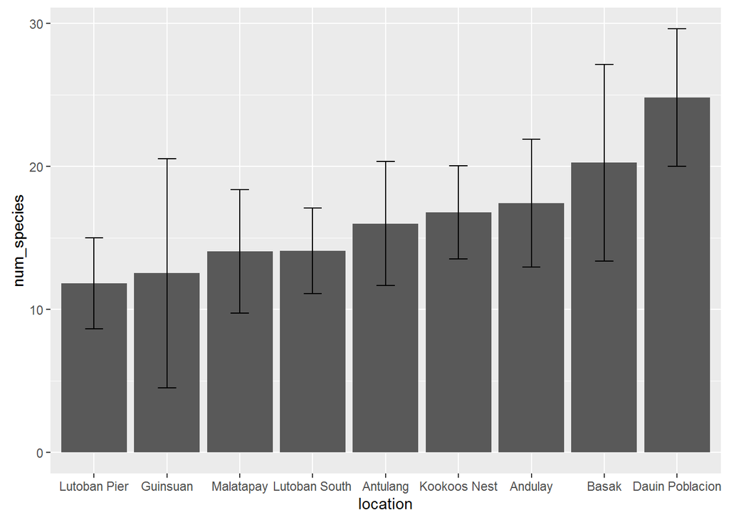

```r
#create the plot
plt.num_species_summary <- ggplot(plotdata, aes(x=location, y=num_species))
#add the bars
plt.num_species_summary <- plt.num_species_summary + geom_bar(stat="identity")
#add the errorbars
plt.num_species_summary <- plt.num_species_summary + geom_errorbar(aes(ymax = plotdata$num_species_sd_min, ymin = plotdata$num_species_sd_max), width=0.25)
#show the plot
plt.num_species_summary
```

Now let’s do the same for the nursery species.

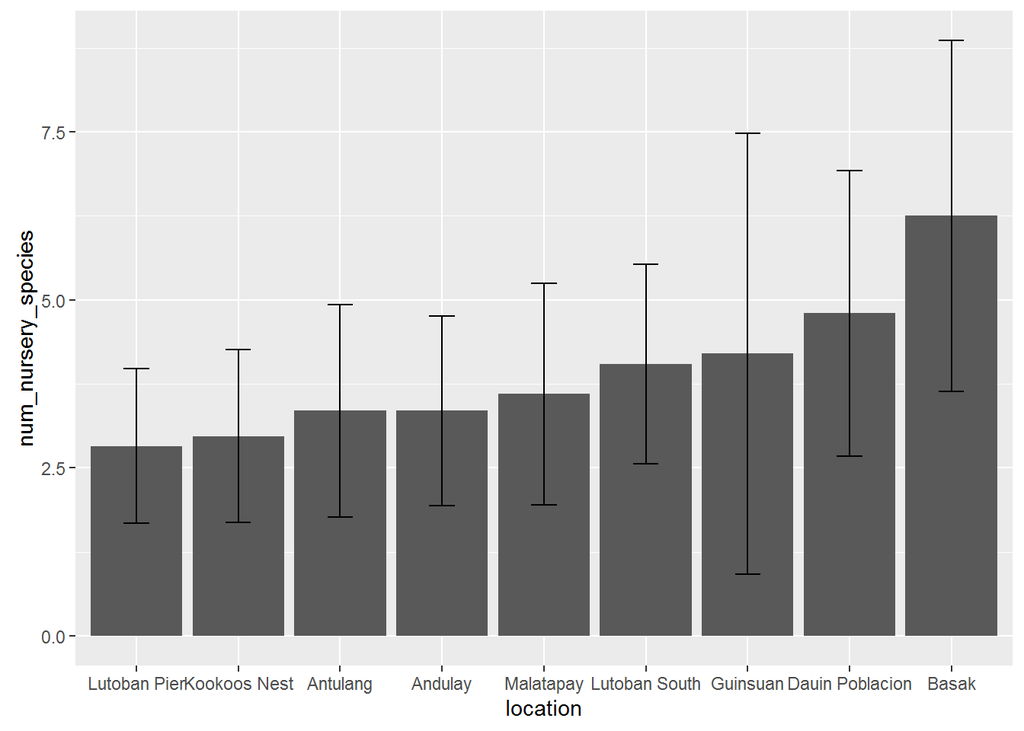

```r
#first we need to re-order the locations according to the number of nursery species.
ordered_x <- as.character(plotdata[order(plotdata$num_nursery_species),c("location")])
plotdata$location <- factor(plotdata$location, levels=ordered_x)

plt.num_nursery_species_summary <- ggplot(plotdata, aes(x=location, y=num_nursery_species))
plt.num_nursery_species_summary <- plt.num_nursery_species_summary + geom_bar(stat="identity")
plt.num_nursery_species_summary <- plt.num_nursery_species_summary + geom_errorbar(aes(ymax = plotdata$num_nursery_species_sd_min, ymin = plotdata$num_nursery_species_sd_max), width=0.25)
plt.num_nursery_species_summary
```

## A GLM test

So now let’s do a GLM test. I’ll make a small list of species and loop over those to do the same GLM on their abundance for each of them. There are various ways of making a list of species. See the examples below.

```r
#These are all our species:
df.species_all$colname
```

```
##   [1] "abudefduf_lorenzi"              "abudefduf_sexfasciatus"
##   [3] "abudefduf_vaigiensis"           "acanthuridae"
##   [5] "acanthurus_mata"                "acanthurus_pyroferus"
##   [7] "acanthurus_thompsoni"           "amanses_scopas"
##   [9] "arothron_nigropuncatus"         "balistoides_viridescens"
##  [11] "bodianus_dictynna"              "caesio_caerularea"
##  [13] "canthigaster_valentini"         "centropyge_tibicen"
##  [15] "cephalopholis_argus"            "cephalopholis_boenak"
##  [17] "chaetodon_ornatissimus"         "chaetodon_punctatofasciatus"
##  [19] "chaetodon_rafflesi"             "chaetodon_speculum"
##  [21] "chaetodon_triangulum"           "chaetodon_vagabundus"
##  [23] "chaetodontidae"                 "chaetodontoplus_mesoleucus"
##  [25] "cheilinus_chlorourus"           "cheilinus_undulatus"
##  [27] "cheilio_inermis"                "cheilodipterus_quinquelineatus"
##  [29] "chlorurus_bleekeri"             "chlorurus_sordidus"
```

[output cut: 37 more lines]

```r
#We can make a list by just typing there names like this:
my_species <- c("parupeneus_barberinoides","lutjanus_fulviflamma","plectropomus_areolatus","chaetodon_vagabundus")
#Another option is just to select the first 10 species like this
my_species <- df.species_all$colname[1:10]
#Or species 1,5,10,35 and 98
my_species <- df.species_all$colname[c(1,5,10,35,98)]
```

We also still need to add out site data (distance to nursery habitat and such) to our `df.sample_data` dataframe. This will give us a few extra variables still that we can use in our GLM and other analyses. We already saved the site data in the `df.sites` data frame, so we can join (merge) that one with the `df.sample_data` dataframe by joining on the location names (called location in df.sample_data and name in df.sites).

```r
df.sample_data <- merge(x=df.sample_data, y=df.sites, by.x="location", by.y="name", all.x=TRUE)
```

Now lets loop over those species and do a GLM for the abundance of each of them against the distance to seagrass.

We select all data in the species column with `df.sample_data[,c(sp)]` and make a formula with that. This formula only tests the abundance of the species agains the distance to seagrass. You can extend the fomula by add multiple variables and also testing the interaction between them. We print the resulting summary. This will tell you the `Pr(|t|)` which is the p-value for the specific model parameter.For more information on regression in R see the awesome documentation on http://www.ats.ucla.edu/stat/dae/ and the presentation on http://www.pitt.edu/~njc23/Lecture10.pdf.

Aside from printing the test results, we also need to see if we can actually use our model results. We do this by judging if the residuals of our model are normally distributed (or in other words, only random variation is left), and if the residuals are evenly distributed over the fitted values. You can judge this visually in the following plots.

```
## [1] "abudefduf_lorenzi"
##
## Call:
## glm(formula = df.sample_data[, c(sp)] ~ df.sample_data$distance_seagrass)
##
## Deviance Residuals:
##    Min      1Q  Median      3Q     Max
##  -0.05    0.00    0.00    0.00    1.95
##
## Coefficients:
##                                       Estimate Std. Error t value Pr(>|t|)
## (Intercept)                          2.695e-17  1.664e-02   0.000   1.0000
## df.sample_data$distance_seagrass106 -4.396e-17  2.354e-02   0.000   1.0000
## df.sample_data$distance_seagrass15  -2.687e-17  2.038e-02   0.000   1.0000
## df.sample_data$distance_seagrass22   5.000e-02  2.354e-02   2.124   0.0343
## df.sample_data$distance_seagrass25   4.458e-31  2.354e-02   0.000   1.0000
## df.sample_data$distance_seagrass49   4.760e-31  2.354e-02   0.000   1.0000
## df.sample_data$distance_seagrass9    3.346e-31  2.354e-02   0.000   1.0000
## df.sample_data$distance_seagrassNA   4.520e-31  2.354e-02   0.000   1.0000
##
## (Intercept)
## df.sample_data$distance_seagrass106
## df.sample_data$distance_seagrass15
## df.sample_data$distance_seagrass22  *
## df.sample_data$distance_seagrass25
## df.sample_data$distance_seagrass49
## df.sample_data$distance_seagrass9
## df.sample_data$distance_seagrassNA
## ---
## Signif. codes:  0 '***' 0.001 '**' 0.01 '*' 0.05 '.' 0.1 ' ' 1
##
## (Dispersion parameter for gaussian family taken to be 0.01107955)
##
##     Null deviance: 3.9889  on 359  degrees of freedom
## Residual deviance: 3.9000  on 352  degrees of freedom
## AIC: -589.41
##
## Number of Fisher Scoring iterations: 2
```

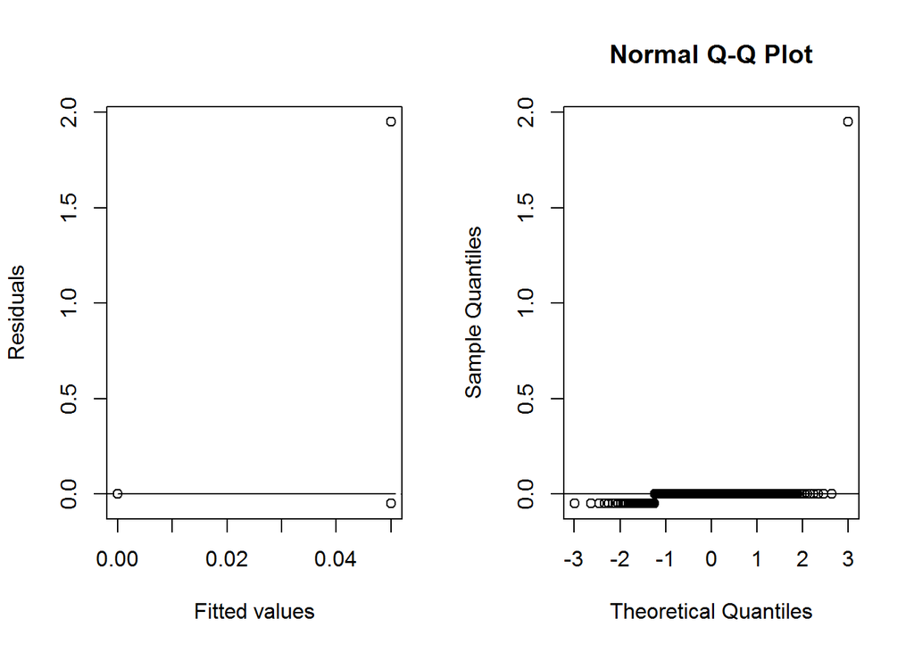

```
## [1] "acanthurus_mata"
##
## Call:
## glm(formula = df.sample_data[, c(sp)] ~ df.sample_data$distance_seagrass)
##
## Deviance Residuals:
##    Min      1Q  Median      3Q     Max
## -0.600  -0.375  -0.100   0.000  13.625
##
## Coefficients:
##                                     Estimate Std. Error t value Pr(>|t|)
## (Intercept)                           0.6000     0.1868   3.213  0.00144
## df.sample_data$distance_seagrass106  -0.3250     0.2641  -1.231  0.21932
## df.sample_data$distance_seagrass15   -0.2250     0.2287  -0.984  0.32594
## df.sample_data$distance_seagrass22   -0.6000     0.2641  -2.272  0.02370
## df.sample_data$distance_seagrass25   -0.6000     0.2641  -2.272  0.02370
## df.sample_data$distance_seagrass49   -0.4250     0.2641  -1.609  0.10848
## df.sample_data$distance_seagrass9    -0.5750     0.2641  -2.177  0.03014
## df.sample_data$distance_seagrassNA   -0.6000     0.2641  -2.272  0.02370
##
## (Intercept)                         **
## df.sample_data$distance_seagrass106
## df.sample_data$distance_seagrass15
## df.sample_data$distance_seagrass22  *
## df.sample_data$distance_seagrass25  *
## df.sample_data$distance_seagrass49
## df.sample_data$distance_seagrass9   *
## df.sample_data$distance_seagrassNA  *
## ---
## Signif. codes:  0 '***' 0.001 '**' 0.01 '*' 0.05 '.' 0.1 ' ' 1
##
## (Dispersion parameter for gaussian family taken to be 1.395099)
##
##     Null deviance: 506.20  on 359  degrees of freedom
## Residual deviance: 491.07  on 352  degrees of freedom
## AIC: 1151.4
##
## Number of Fisher Scoring iterations: 2
```

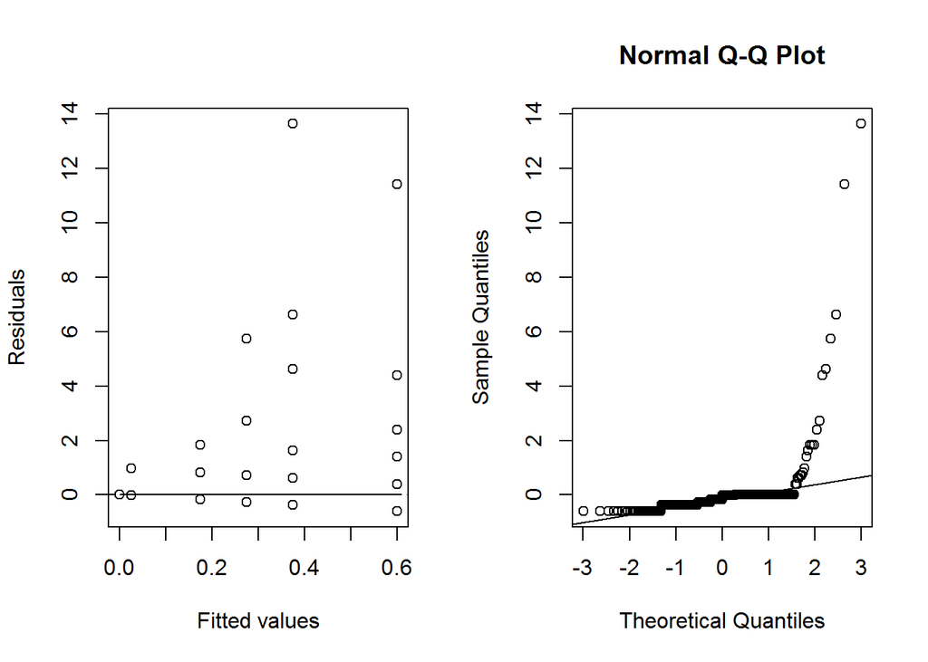

```
## [1] "balistoides_viridescens"
##
## Call:
## glm(formula = df.sample_data[, c(sp)] ~ df.sample_data$distance_seagrass)
##
## Deviance Residuals:
##     Min       1Q   Median       3Q      Max
## -0.0500  -0.0250  -0.0125   0.0000   0.9875
##
## Coefficients:
##                                       Estimate Std. Error t value Pr(>|t|)
## (Intercept)                          2.500e-02  1.854e-02   1.349    0.178
## df.sample_data$distance_seagrass106 -2.500e-02  2.621e-02  -0.954    0.341
## df.sample_data$distance_seagrass15  -1.250e-02  2.270e-02  -0.551    0.582
## df.sample_data$distance_seagrass22  -2.500e-02  2.621e-02  -0.954    0.341
## df.sample_data$distance_seagrass25  -2.500e-02  2.621e-02  -0.954    0.341
## df.sample_data$distance_seagrass49   2.500e-02  2.621e-02   0.954    0.341
## df.sample_data$distance_seagrass9   -2.500e-02  2.621e-02  -0.954    0.341
## df.sample_data$distance_seagrassNA   5.586e-18  2.621e-02   0.000    1.000
##
## (Dispersion parameter for gaussian family taken to be 0.0137429)
##
##     Null deviance: 4.9306  on 359  degrees of freedom
## Residual deviance: 4.8375  on 352  degrees of freedom
## AIC: -511.86
##
## Number of Fisher Scoring iterations: 2
```

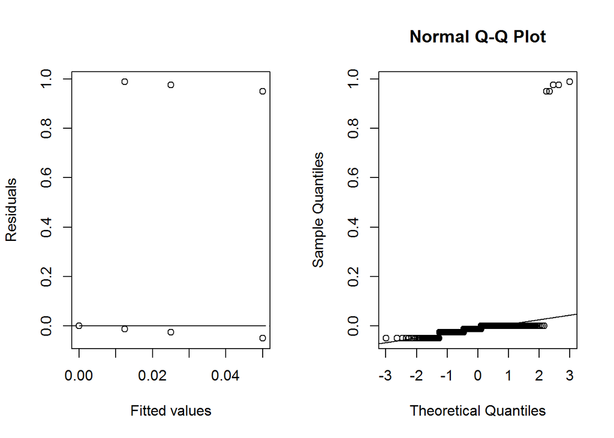

```
## [1] "epinephelus_fuscoguttatus"
##
## Call:
## glm(formula = df.sample_data[, c(sp)] ~ df.sample_data$distance_seagrass)
##
## Deviance Residuals:
##    Min      1Q  Median      3Q     Max
##      0       0       0       0       0
##
## Coefficients:
##                                     Estimate Std. Error t value Pr(>|t|)
## (Intercept)                                0          0      NA       NA
## df.sample_data$distance_seagrass106        0          0      NA       NA
## df.sample_data$distance_seagrass15         0          0      NA       NA
## df.sample_data$distance_seagrass22         0          0      NA       NA
## df.sample_data$distance_seagrass25         0          0      NA       NA
## df.sample_data$distance_seagrass49         0          0      NA       NA
## df.sample_data$distance_seagrass9          0          0      NA       NA
## df.sample_data$distance_seagrassNA         0          0      NA       NA
##
## (Dispersion parameter for gaussian family taken to be 0)
##
##     Null deviance: 0  on 359  degrees of freedom
## Residual deviance: 0  on 352  degrees of freedom
## AIC: -Inf
##
## Number of Fisher Scoring iterations: 1
```

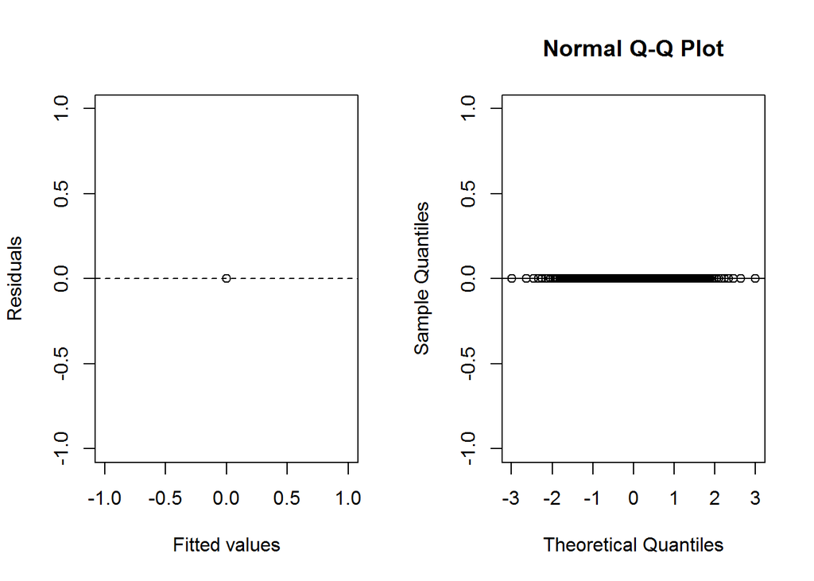

```
## [1] "parupeneus_barberinoides"
##
## Call:
## glm(formula = df.sample_data[, c(sp)] ~ df.sample_data$distance_seagrass)
##
## Deviance Residuals:
##     Min       1Q   Median       3Q      Max
## -2.7000  -0.1625   0.0000   0.0000   4.7250
##
## Coefficients:
##                                     Estimate Std. Error t value Pr(>|t|)
## (Intercept)                           0.2750     0.1486   1.851    0.065
## df.sample_data$distance_seagrass106  -0.2750     0.2101  -1.309    0.191
## df.sample_data$distance_seagrass15   -0.1125     0.1820  -0.618    0.537
## df.sample_data$distance_seagrass22    2.4250     0.2101  11.542   <2e-16
## df.sample_data$distance_seagrass25   -0.2750     0.2101  -1.309    0.191
## df.sample_data$distance_seagrass49   -0.2750     0.2101  -1.309    0.191
## df.sample_data$distance_seagrass9    -0.0250     0.2101  -0.119    0.905
## df.sample_data$distance_seagrassNA   -0.2750     0.2101  -1.309    0.191
##
## (Intercept)                         .
## df.sample_data$distance_seagrass106
## df.sample_data$distance_seagrass15
## df.sample_data$distance_seagrass22  ***
## df.sample_data$distance_seagrass25
## df.sample_data$distance_seagrass49
## df.sample_data$distance_seagrass9
## df.sample_data$distance_seagrassNA
## ---
## Signif. codes:  0 '***' 0.001 '**' 0.01 '*' 0.05 '.' 0.1 ' ' 1
##
## (Dispersion parameter for gaussian family taken to be 0.882848)
##
##     Null deviance: 553.99  on 359  degrees of freedom
## Residual deviance: 310.76  on 352  degrees of freedom
## AIC: 986.69
##
## Number of Fisher Scoring iterations: 2
```

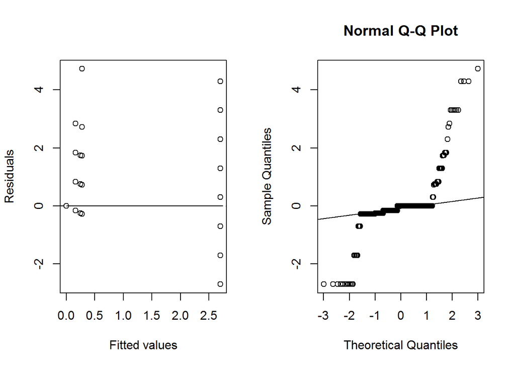

```r
for (sp in my_species){
  print(sp)
  res <- glm(df.sample_data[,c(sp)] ~ df.sample_data$distance_seagrass)
  print(summary(res))
  par(mfrow=c(1,2)) #I want these two plots side by side
  #Make a plot of the fitted values agains the residulas
  plot(fitted(res),residuals(res),xlab="Fitted values", ylab="Residuals", abline(h=0, lty=2))
  tryCatch( #this tryCatch part is to make sure that the code continues if there is an error with fitting the line below.
    lines(smooth.spline(fitted(res), residuals(res))), #Add a smoot line that should be horizontal
    error=function(e){}
  )
  #Create a normal q-q plot to see if the residuals are normally distributed
  qqnorm(res$residuals)
  qqline(res$residuals) #add the solid line on which all points should be located with a normal distrubution.

}
```

```r
par(mfrow=c(1,1)) #for the next plots, I just want the one at a time again. So restore to the standard setting.
```

```r
my_species <- df.species_all$colname_pres[c(1,5,10,35,98)]
for (sp in my_species){
  print(sp)
  res <- glm(df.sample_data[,c(sp)] ~ df.sample_data$distance_seagrass, family="binomial")
  print(summary(res))
}
```

```
## [1] "abudefduf_lorenzi_pres"
##
## Call:
## glm(formula = df.sample_data[, c(sp)] ~ df.sample_data$distance_seagrass,
##     family = "binomial")
##
## Deviance Residuals:
##      Min        1Q    Median        3Q       Max
## -0.22502  -0.00001  -0.00001  -0.00001   2.71620
##
## Coefficients:
##                                       Estimate Std. Error z value Pr(>|z|)
## (Intercept)                         -2.357e+01  1.256e+04  -0.002    0.999
## df.sample_data$distance_seagrass106  5.591e-11  1.777e+04   0.000    1.000
## df.sample_data$distance_seagrass15   8.862e-14  1.539e+04   0.000    1.000
## df.sample_data$distance_seagrass22   1.990e+01  1.256e+04   0.002    0.999
## df.sample_data$distance_seagrass25  -5.148e-22  1.777e+04   0.000    1.000
## df.sample_data$distance_seagrass49  -5.205e-22  1.777e+04   0.000    1.000
## df.sample_data$distance_seagrass9   -5.170e-22  1.777e+04   0.000    1.000
## df.sample_data$distance_seagrassNA  -5.267e-22  1.777e+04   0.000    1.000
##
## (Dispersion parameter for binomial family taken to be 1)
##
##     Null deviance: 13.7694  on 359  degrees of freedom
## Residual deviance:  9.3525  on 352  degrees of freedom
## AIC: 25.353
##
## Number of Fisher Scoring iterations: 22
##
## [1] "acanthurus_mata_pres"
##
## Call:
## glm(formula = df.sample_data[, c(sp)] ~ df.sample_data$distance_seagrass,
##     family = "binomial")
##
## Deviance Residuals:
##      Min        1Q    Median        3Q       Max
## -0.57012  -0.45904  -0.30995  -0.00008   2.71620
##
## Coefficients:
```

[output cut: 55 more lines]

```
## df.sample_data$distance_seagrass49
## df.sample_data$distance_seagrass9
## df.sample_data$distance_seagrassNA
## ---
## Signif. codes:  0 '***' 0.001 '**' 0.01 '*' 0.05 '.' 0.1 ' ' 1
##
## (Dispersion parameter for binomial family taken to be 1)
##
##     Null deviance: 52.697  on 359  degrees of freedom
## Residual deviance: 45.338  on 352  degrees of freedom
## AIC: 61.338
##
## Number of Fisher Scoring iterations: 20
##
## [1] "epinephelus_fuscoguttatus_pres"
```

```
##
## Call:
## glm(formula = df.sample_data[, c(sp)] ~ df.sample_data$distance_seagrass,
##     family = "binomial")
##
## Deviance Residuals:
##        Min          1Q      Median          3Q         Max
## -2.409e-06  -2.409e-06  -2.409e-06  -2.409e-06  -2.409e-06
##
## Coefficients:
##                                       Estimate Std. Error z value Pr(>|z|)
## (Intercept)                         -2.657e+01  5.631e+04       0        1
## df.sample_data$distance_seagrass106  7.275e-13  7.963e+04       0        1
## df.sample_data$distance_seagrass15  -7.940e-27  6.896e+04       0        1
## df.sample_data$distance_seagrass22  -7.880e-27  7.963e+04       0        1
## df.sample_data$distance_seagrass25  -9.263e-27  7.963e+04       0        1
## df.sample_data$distance_seagrass49  -8.696e-27  7.963e+04       0        1
## df.sample_data$distance_seagrass9   -7.829e-27  7.963e+04       0        1
## df.sample_data$distance_seagrassNA  -7.967e-27  7.963e+04       0        1
##
## (Dispersion parameter for binomial family taken to be 1)
##
##     Null deviance: 0.0000e+00  on 359  degrees of freedom
## Residual deviance: 2.0886e-09  on 352  degrees of freedom
## AIC: 16
##
## Number of Fisher Scoring iterations: 25
##
## [1] "parupeneus_barberinoides_pres"
##
## Call:
## glm(formula = df.sample_data[, c(sp)] ~ df.sample_data$distance_seagrass,
##     family = "binomial")
##
## Deviance Residuals:
##      Min        1Q    Median        3Q       Max
## -1.55176  -0.45904  -0.00005  -0.00005   2.14597
##
## Coefficients:
##                                       Estimate Std. Error z value Pr(>|z|)
```

[output cut: 12 more lines]

```
## df.sample_data$distance_seagrass22  ***
## df.sample_data$distance_seagrass25
## df.sample_data$distance_seagrass49
## df.sample_data$distance_seagrass9
## df.sample_data$distance_seagrassNA
## ---
## Signif. codes:  0 '***' 0.001 '**' 0.01 '*' 0.05 '.' 0.1 ' ' 1
##
## (Dispersion parameter for binomial family taken to be 1)
##
##     Null deviance: 282.73  on 359  degrees of freedom
## Residual deviance: 166.92  on 352  degrees of freedom
## AIC: 182.92
##
## Number of Fisher Scoring iterations: 19
```

## Dirkje prutsels

Nursery species columns: 1:3,25:28,36,39,40,42,47,52:54,58,66,84:86,88,91:100,102:104

# ANOVA

```r
  res <- aov(df.sample_data$num_nursery_species ~ df.sample_data$location)
  print(summary(res))
```

```
##                          Df Sum Sq Mean Sq F value   Pr(>F)
## df.sample_data$location   8  365.6   45.71   11.95 4.28e-15 ***
## Residuals               351 1342.7    3.83
## ---
## Signif. codes:  0 '***' 0.001 '**' 0.01 '*' 0.05 '.' 0.1 ' ' 1
```

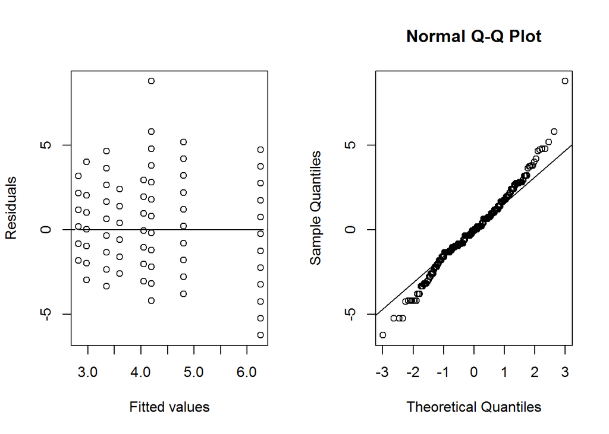

```r
  par(mfrow=c(1,2))
  plot(fitted(res),residuals(res),xlab="Fitted values", ylab="Residuals", abline(h=0, lty=2))
  tryCatch(
    lines(smooth.spline(fitted(res), residuals(res))),
    error=function(e){}
  )

    qqnorm(res$residuals)
  qqline(res$residuals)
```

```r
  shapiro.test(res$residuals) #no normal distribution
```

```
##
##  Shapiro-Wilk normality test
##
## data:  res$residuals
## W = 0.98304, p-value = 0.0003061
```

```r
  kruskal.test(df.sample_data$num_nursery_species ~ df.sample_data$location) #nonidentical populations
```

```
##
##  Kruskal-Wallis rank sum test
##
## data:  df.sample_data$num_nursery_species by df.sample_data$location
## Kruskal-Wallis chi-squared = 67.832, df = 8, p-value = 1.326e-11
```

```r
  TukeyHSD(x=res, 'df.sample_data$location', conf.level=0.95)
```

```
##   Tukey multiple comparisons of means
##     95% family-wise confidence level
##
## Fit: aov(formula = df.sample_data$num_nursery_species ~ df.sample_data$location)
##
## $`df.sample_data$location`
##                                        diff         lwr          upr
## Guinsuan-Antulang              8.500000e-01 -0.51508621  2.215086211
## Malatapay-Antulang             2.500000e-01 -1.11508621  1.615086211
## Andulay-Antulang               1.687539e-14 -1.36508621  1.365086211
## Basak-Antulang                 2.900000e+00  1.53491379  4.265086211
## Lutoban South-Antulang         7.000000e-01 -0.66508621  2.065086211
## Lutoban Pier-Antulang         -5.250000e-01 -1.89008621  0.840086211
## Kookoos Nest-Antulang         -3.750000e-01 -1.74008621  0.990086211
## Dauin Poblacion-Antulang       1.450000e+00  0.08491379  2.815086211
## Malatapay-Guinsuan            -6.000000e-01 -1.96508621  0.765086211
## Andulay-Guinsuan              -8.500000e-01 -2.21508621  0.515086211
## Basak-Guinsuan                 2.050000e+00  0.68491379  3.415086211
## Lutoban South-Guinsuan        -1.500000e-01 -1.51508621  1.215086211
## Lutoban Pier-Guinsuan         -1.375000e+00 -2.74008621 -0.009913789
## Kookoos Nest-Guinsuan         -1.225000e+00 -2.59008621  0.140086211
## Dauin Poblacion-Guinsuan       6.000000e-01 -0.76508621  1.965086211
## Andulay-Malatapay             -2.500000e-01 -1.61508621  1.115086211
## Basak-Malatapay                2.650000e+00  1.28491379  4.015086211
## Lutoban South-Malatapay        4.500000e-01 -0.91508621  1.815086211
## Lutoban Pier-Malatapay        -7.750000e-01 -2.14008621  0.590086211
## Kookoos Nest-Malatapay        -6.250000e-01 -1.99008621  0.740086211
## Dauin Poblacion-Malatapay      1.200000e+00 -0.16508621  2.565086211
## Basak-Andulay                  2.900000e+00  1.53491379  4.265086211
## Lutoban South-Andulay          7.000000e-01 -0.66508621  2.065086211
## Lutoban Pier-Andulay          -5.250000e-01 -1.89008621  0.840086211
## Kookoos Nest-Andulay          -3.750000e-01 -1.74008621  0.990086211
## Dauin Poblacion-Andulay        1.450000e+00  0.08491379  2.815086211
## Lutoban South-Basak           -2.200000e+00 -3.56508621 -0.834913789
## Lutoban Pier-Basak            -3.425000e+00 -4.79008621 -2.059913789
## Kookoos Nest-Basak            -3.275000e+00 -4.64008621 -1.909913789
## Dauin Poblacion-Basak         -1.450000e+00 -2.81508621 -0.084913789
## Lutoban Pier-Lutoban South    -1.225000e+00 -2.59008621  0.140086211
## Kookoos Nest-Lutoban South    -1.075000e+00 -2.44008621  0.290086211
## Dauin Poblacion-Lutoban South  7.500000e-01 -0.61508621  2.115086211
```

[output cut: 25 more lines]

```
## Basak-Andulay                 0.0000000
## Lutoban South-Andulay         0.8041557
## Lutoban Pier-Andulay          0.9560810
## Kookoos Nest-Andulay          0.9948748
## Dauin Poblacion-Andulay       0.0277824
## Lutoban South-Basak           0.0000275
## Lutoban Pier-Basak            0.0000000
## Kookoos Nest-Basak            0.0000000
## Dauin Poblacion-Basak         0.0277824
## Lutoban Pier-Lutoban South    0.1187431
## Kookoos Nest-Lutoban South    0.2564502
## Dauin Poblacion-Lutoban South 0.7371108
## Kookoos Nest-Lutoban Pier     0.9999945
## Dauin Poblacion-Lutoban Pier  0.0002937
## Dauin Poblacion-Kookoos Nest  0.0012493
```

```r
  library(agricolae)
  HSD.test(res,'df.sample_data$location',group=TRUE)
```

[output not shown]

# Logistic regression ; on presence

Seagrass only

```r
my_nur_species <- df.species_all$colname_pres[c(1:3)]
for (sp in my_nur_species){
  print(sp)
  res <- glm(df.sample_data[,c(sp)] ~ df.sample_data$distance_seagrass + df.sample_data$size_seagrass, family="binomial")
  print(summary(res))
}
```

```
## [1] "abudefduf_lorenzi_pres"
##
## Call:
## glm(formula = df.sample_data[, c(sp)] ~ df.sample_data$distance_seagrass +
##     df.sample_data$size_seagrass, family = "binomial")
##
## Deviance Residuals:
##      Min        1Q    Median        3Q       Max
## -0.22502  -0.00001  -0.00001  -0.00001   2.71620
##
## Coefficients: (7 not defined because of singularities)
##                                       Estimate Std. Error z value Pr(>|z|)
## (Intercept)                         -2.357e+01  1.256e+04  -0.002    0.999
## df.sample_data$distance_seagrass106  5.591e-11  1.777e+04   0.000    1.000
## df.sample_data$distance_seagrass15   8.862e-14  1.777e+04   0.000    1.000
## df.sample_data$distance_seagrass22   1.990e+01  1.256e+04   0.002    0.999
## df.sample_data$distance_seagrass25  -5.148e-22  1.777e+04   0.000    1.000
## df.sample_data$distance_seagrass49  -5.205e-22  1.777e+04   0.000    1.000
## df.sample_data$distance_seagrass9   -5.170e-22  1.777e+04   0.000    1.000
## df.sample_data$distance_seagrassNA  -5.267e-22  1.777e+04   0.000    1.000
## df.sample_data$size_seagrass0.01            NA         NA      NA       NA
## df.sample_data$size_seagrass0.13    -1.577e-26  1.777e+04   0.000    1.000
## df.sample_data$size_seagrass0.15            NA         NA      NA       NA
## df.sample_data$size_seagrass1.83            NA         NA      NA       NA
## df.sample_data$size_seagrass15.18           NA         NA      NA       NA
## df.sample_data$size_seagrass15.34           NA         NA      NA       NA
## df.sample_data$size_seagrass3.89            NA         NA      NA       NA
## df.sample_data$size_seagrassNA              NA         NA      NA       NA
##
## (Dispersion parameter for binomial family taken to be 1)
##
##     Null deviance: 13.7694  on 359  degrees of freedom
## Residual deviance:  9.3525  on 351  degrees of freedom
## AIC: 27.353
##
## Number of Fisher Scoring iterations: 22
##
## [1] "abudefduf_sexfasciatus_pres"
##
## Call:
```

[output cut: 93 more lines]

```
## df.sample_data$size_seagrass1.83
## df.sample_data$size_seagrass15.18
## df.sample_data$size_seagrass15.34
## df.sample_data$size_seagrass3.89
## df.sample_data$size_seagrassNA
## ---
## Signif. codes:  0 '***' 0.001 '**' 0.01 '*' 0.05 '.' 0.1 ' ' 1
##
## (Dispersion parameter for binomial family taken to be 1)
##
##     Null deviance: 343.02  on 359  degrees of freedom
## Residual deviance: 258.37  on 351  degrees of freedom
## AIC: 276.37
##
## Number of Fisher Scoring iterations: 17
```

Seagrass with mangroves

```r
for (sp in my_nur_species){
  print(sp)
  res <- glm(df.sample_data[,c(sp)] ~ df.sample_data$distance_seagrass + df.sample_data$distance_mangroves + df.sample_data$size_seagrass + df.sample_data$size_mangroves, family="binomial")
  print(summary(res))
}
```

```
## [1] "abudefduf_lorenzi_pres"
##
## Call:
## glm(formula = df.sample_data[, c(sp)] ~ df.sample_data$distance_seagrass +
##     df.sample_data$distance_mangroves + df.sample_data$size_seagrass +
##     df.sample_data$size_mangroves, family = "binomial")
##
## Deviance Residuals:
##      Min        1Q    Median        3Q       Max
## -0.22502  -0.00001  -0.00001  -0.00001   2.71620
##
## Coefficients: (9 not defined because of singularities)
##                                       Estimate Std. Error z value Pr(>|z|)
## (Intercept)                         -2.357e+01  1.337e+04  -0.002    0.999
## df.sample_data$distance_seagrass106  5.591e-11  1.821e+04   0.000    1.000
## df.sample_data$distance_seagrass15   8.862e-14  1.712e+04   0.000    1.000
## df.sample_data$distance_seagrass22   1.990e+01  1.262e+04   0.002    0.999
## df.sample_data$distance_seagrass25  -9.232e-22  1.819e+04   0.000    1.000
## df.sample_data$distance_seagrass49  -1.972e-22  1.804e+04   0.000    1.000
## df.sample_data$distance_seagrass9   -6.498e-22  1.781e+04   0.000    1.000
## df.sample_data$distance_seagrassNA  -1.236e-21  1.902e+04   0.000    1.000
## df.sample_data$distance_mangroves    2.506e-24  2.398e+01   0.000    1.000
## df.sample_data$size_seagrass0.01            NA         NA      NA       NA
## df.sample_data$size_seagrass0.13            NA         NA      NA       NA
## df.sample_data$size_seagrass0.15            NA         NA      NA       NA
## df.sample_data$size_seagrass1.83            NA         NA      NA       NA
## df.sample_data$size_seagrass15.18           NA         NA      NA       NA
## df.sample_data$size_seagrass15.34           NA         NA      NA       NA
## df.sample_data$size_seagrass3.89            NA         NA      NA       NA
## df.sample_data$size_seagrassNA              NA         NA      NA       NA
## df.sample_data$size_mangroves               NA         NA      NA       NA
##
## (Dispersion parameter for binomial family taken to be 1)
##
##     Null deviance: 13.7694  on 359  degrees of freedom
## Residual deviance:  9.3525  on 351  degrees of freedom
## AIC: 27.353
##
## Number of Fisher Scoring iterations: 22
##
```

[output cut: 106 more lines]

```
## df.sample_data$size_seagrass15.18
## df.sample_data$size_seagrass15.34
## df.sample_data$size_seagrass3.89
## df.sample_data$size_seagrassNA
## df.sample_data$size_mangroves
## ---
## Signif. codes:  0 '***' 0.001 '**' 0.01 '*' 0.05 '.' 0.1 ' ' 1
##
## (Dispersion parameter for binomial family taken to be 1)
##
##     Null deviance: 343.02  on 359  degrees of freedom
## Residual deviance: 258.37  on 351  degrees of freedom
## AIC: 276.37
##
## Number of Fisher Scoring iterations: 17
```